# Fuel Economy and Vehicle

Chun En Chu & Hsiang Yu Wen

12/6/2020

### Use case

1. The aim of the application is to find a friendly car type for “customers” by analyzing the GHG Score, Fuel Cost and Energy Cost in terms of manufactures, fuel types, model year, and car types.
2. The application is designed for people who have the interest to buy a car.

### Required Packages

1. For running this app, we need our users to run the the following packages:
   - shiny - For app
   - shinydashboard - customize UI
   - shinyWidgets - setting screen
   - shinythemes - themes
   - DT - For data table
   - plotly - For plot
   - tidyverse - For tidy
   - reactlog - Reactive Visualizer
   - lazyeval - For plot

### Data Source and Structure

1. Data source
   - www.fueleconomy.gov

[figure not shown]

   - There are 43098 rows and 83 columns. The data shows lots of information about the vehicle such as model, make, fuel type, as a categorical variable and city08, ghgscore, fuelCost08 as quantitative variable. In fueltype, the data separate into 16 variables. The unknow value inside the data is displayed as NA.

### EDA Inputs, Controls, and Outputs

1. We can choose different tab on the left as the screenshot shows.

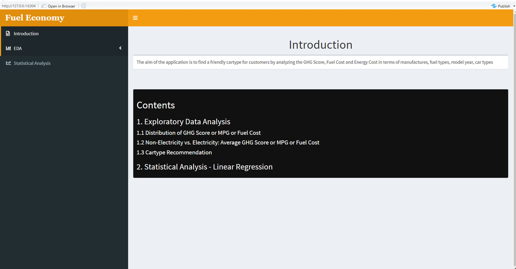

2. The first tab of Distribution of GHG Score/MPG/Cost

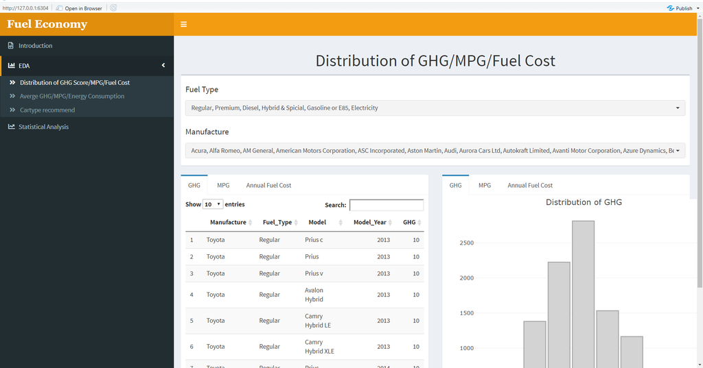

   - Users can choose the fuel type and the car manufacture by their own will.
   - Users can choose GHG(Green house gas), MPG(Miles per gallon), and annual fuel cost to analyze what car they have interest.
   - We also add a plot on the right for users.
3. The second one is Average GHG/MPG/Energy Consumption

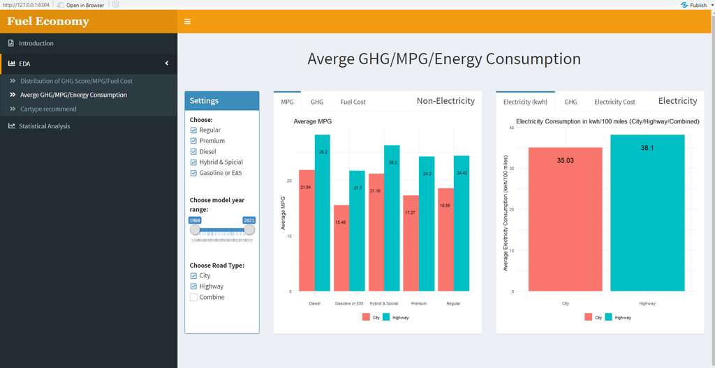

   - Users can choose different road types to compare different fuel type.
   - Users can select the year range on the left.
   - We found that except the electricity, the other fuel type can go further on the highway. For electricity car on the highway, it costs more power than in the city.
4. Based on the analyze of above. The last one is for users to choose any car they would like to buy.

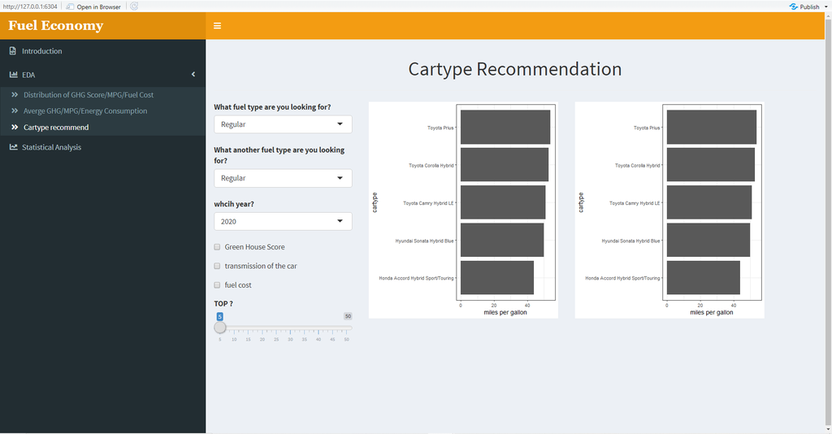

   - The first two select inputs and choose the fuel type of car, by choosing different fuel type user can compare different fuel type car by showing the difference of MPG(miles per gallon) for each car.
   - The check box for green house score that user can know how clean those picked car is. Sometime there has a duplicated in car-type so transmission check box can help the use know the difference easily. By clicking the fuel cost button user can also know about the cost of the car while showing the MPG.
   - Users can use the slide bar to choose how many cars they would like to see and compared.

### Statistical Analysis Inputs, Controls, and Outputs

1. Statistical Analysis part

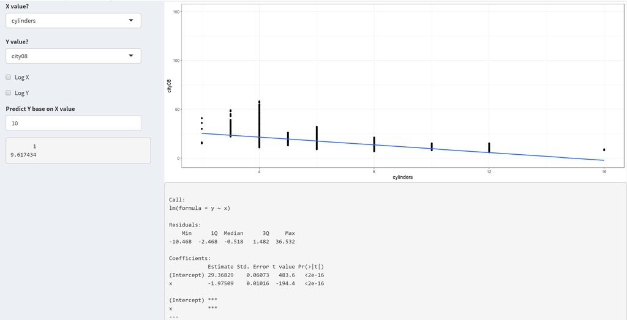